# UNICEF Youth Literacy & Water Access Dashboard

## 7 📉 Visualisation 4 — Time-Series: Global Water Access Trend

Educational infrastructure cannot exist in a vacuum; human survivability metrics form the bedrock of community stability. This time-series explores the global progression of minimum basic water security over the last two decades. The smoothed LOESS trendline showcases a persistent, encouraging upward trajectory, reflecting the massive success of global humanitarian programs to build wells and sanitisation systems. Yet, the remaining percentage gap preventing 100% saturation represents populations explicitly anchored in survival mode—where millions of youths, particularly young girls, are often tasked with extensive daily basic resource gathering rather than attending their local schools.

**🌊 Generate Time-Series Visualization**

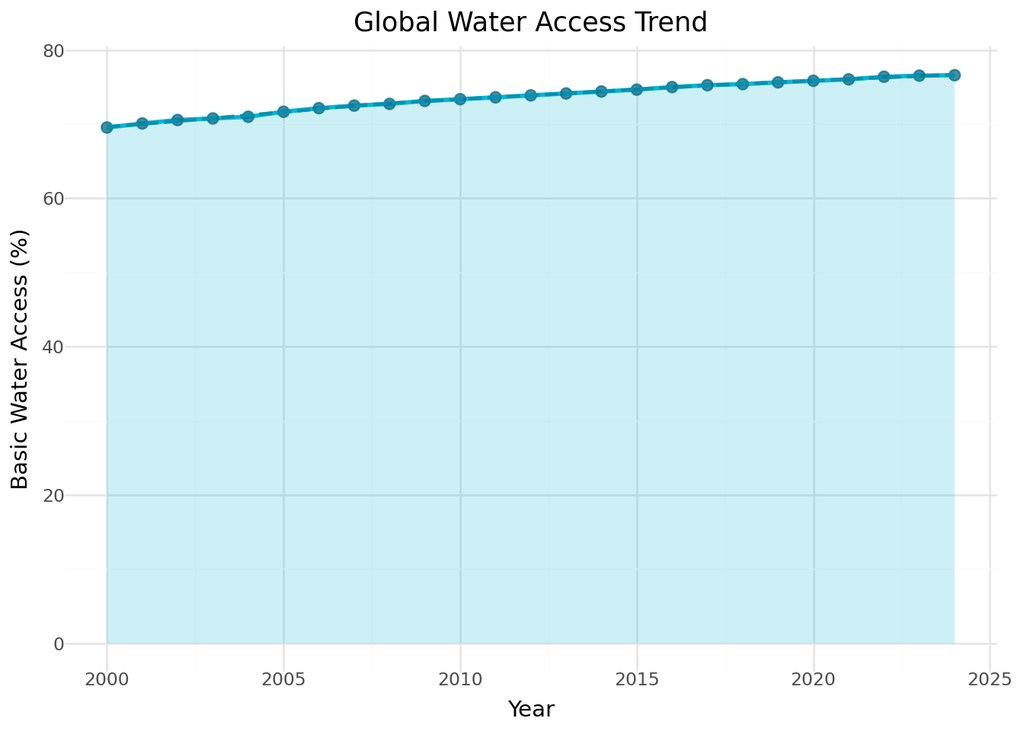

Figure 4: Global Average Basic Water Access Over Time

```python
water_ts = water_df.with_columns(pl.col(w_year_col).cast(pl.Int64, strict=False).alias("year")).drop_nulls(subset=["year", "obs_value"]).group_by("year").agg(pl.col("obs_value").mean().alias("avg_water")).sort("year")

p4 = (
    ggplot(water_ts, aes(x="year", y="avg_water"))
    + geom_area(fill="#06B6D4", alpha=0.2)
    + geom_line(color="#06B6D4", size=1.2)
    + geom_point(color="#0E7490", size=2.5, alpha=0.8)
    + geom_smooth(method="loess", color="#0891B2", linetype="dashed", se=False, span=0.4)
    + labs(title="Global Water Access Trend", x="Year", y="Basic Water Access (%)")
    + theme_minimal()
)
p4
```

**🚰 Compute Time-Series Table Extraction**

```python
from IPython.display import Markdown, display

w_latest = water_df.sort(w_year_col).group_by(alpha_col).last().drop_nulls(subset=["obs_value"]).join(t_latest.select([alpha_col, country_col]), on=alpha_col, how="left")
top5_w = w_latest.sort("obs_value", descending=True).head(5)
bottom5_w = w_latest.sort("obs_value").head(5)

md = "### 🚰 Universal Water Access (Top 5)\n\n"
md += "| Country | Record Year | Basic Water Access (%) |\n"
md += "|:---|:---:|---:|\n"
for r in top5_w.iter_rows(named=True):
    c_name = r[country_col] if r.get(country_col) else r[alpha_col]
    md += f"| **{c_name}** | {r[w_year_col]} | {r['obs_value']:.1f}% |\n"

md += "\n<br>\n\n"

md += "### 🏜️ Critical Water Insecurity (Bottom 5)\n\n"
md += "| Country | Record Year | Basic Water Access (%) |\n"
md += "|:---|:---:|---:|\n"
for r in bottom5_w.iter_rows(named=True):
    c_name = r[country_col] if r.get(country_col) else r[alpha_col]
    md += f"| **{c_name}** | {r[w_year_col]} | {r['obs_value']:.1f}% |\n"

display(Markdown(md))
```

Table 4: Water Access Extremes: Top 5 and Bottom 5

7.1 🚰 Universal Water Access (Top 5)

| Country | Record Year | Basic Water Access (%) |
| --- | --- | --- |
| **Singapore** | 2024 | 100.0% |
| **Macao** | 2024 | 100.0% |
| **Hong Kong** | 2024 | 100.0% |
| **Gibraltar** | 2024 | 100.0% |
| **Liechtenstein** | 2024 | 100.0% |

7.2 🏜️ Critical Water Insecurity (Bottom 5)

| Country | Record Year | Basic Water Access (%) |
| --- | --- | --- |
| **Tuvalu** | 2024 | 8.7% |
| **Sierra Leone** | 2024 | 11.1% |
| **Chad** | 2024 | 13.6% |
| **Kiribati** | 2024 | 15.1% |
| **Nepal** | 2024 | 16.5% |

## 8 References

1. UNICEF Data Warehouse — https://data.unicef.org
2. WHO/UNICEF Joint Monitoring Programme — https://washdata.org
3. World Bank World Development Indicators — https://data.worldbank.org
4. Quarto Documentation — https://quarto.org
5. Polars Documentation — https://docs.pola.rs
6. plotnine Documentation — https://plotnine.org